# Proyecto AED: Análisis de la Calidad de Vida en España

Daniela Meriño, Víctor Mateu, Antonio Nova

2024-12-31

## Introducción

La calidad de vida es un concepto multidimensional que abarca aspectos económicos, sociales, ambientales y subjetivos, reflejando el bienestar general de las personas en una sociedad. En este trabajo, analizaremos la calidad de vida en España, desglosada en diversas dimensiones, a lo largo de varias comunidades autónomas y un periodo de años.

El análisis se centra en múltiples dimensiones de la calidad de vida, como las condiciones materiales, la salud, la educación, el trabajo, las relaciones sociales, la seguridad, el entorno ambiental y la gobernanza, entre otras. Además, el enfoque temporal nos permitirá evaluar tendencias, identificar patrones y observar disparidades entre las diferentes comunidades autónomas.

Los datos utilizados para este estudio provienen de un conjunto estructurado que organiza información clave de calidad de vida por año, comunidad autónoma y dimensión. Este formato permitirá realizar comparaciones entre las regiones y temporales, utilizando herramientas estadísticas y visualizaciones para descubrir las relaciones y diferencias significativas entre las regiones de España.

## Importación y Ordenación de los datos

En este apartado, se procede a la importación y preparación de los datos proporcionados por el Instituto Nacional de Estadística (INE) de España. Los datos corresponden al [**Indicador Multidimensional de Calidad de Vida (IMCV)**](https://ine.es/experimental/imcv/experimental_ind_multi_calidad_vida.htm). Este indicador tiene como objetivo ofrecer una visión integral del bienestar en las distintas comunidades autónomas mediante la evaluación de múltiples dimensiones, como salud, educación, trabajo, entre otras.

Nuestro conjunto de datos se organiza en nueve dimensiones. Estas abarcan aspectos clave como condiciones materiales de vida (renta, pobreza y seguridad económica), trabajo (empleo y calidad laboral), salud (esperanza de vida y determinantes como ejercicio y tabaquismo), educación (formación y abandono escolar), ocio y relaciones sociales (satisfacción y apoyo social), seguridad física (criminalidad y percepción de seguridad), gobernanza (confianza en instituciones y participación política), entorno (contaminación y acceso a zonas verdes) y experiencia de vida (satisfacción y propósito vital). Juntas, estas dimensiones ofrecen una visión del bienestar en las diferentes comunidades autónomas de España.

La naturaleza experimental de estos datos implica que están en proceso de consolidación metodológica y pueden incluir innovaciones en las fuentes de información. En este sentido, el primer paso es garantizar que los datos se encuentren correctamente estructurados y listos para su análisis.

En primer lugar, destacar que de este conjunto de datos utilizada tiene un número muy elevado de variables por lo que nosotros nos centraremos en los resultados globales de cada dimensión por comunidad autónoma por año.

Aunque, para enteder un poco mejor de cómo se han obtenido los datos del conjunto que vamos a analizar, destacar que el cálculo del **Indicador Multidimensional de Calidad de Vida (IMCV)** se basa en la selección de indicadores representativos de nueve dimensiones clave, como condiciones materiales de vida, salud, educación y trabajo, obtenidos de fuentes estadísticas como la Encuesta de Condiciones de Vida. Los valores de cada indicador se normalizan para permitir comparaciones homogéneas mediante el método Mazziotta-Pareto Ajustado (AMPI), que reescala los datos en un rango común y penaliza la variabilidad excesiva. Posteriormente, se agregan los valores normalizados de cada dimensión en un índice representativo, y finalmente, los índices de todas las dimensiones se combinan en un único valor global mediante una media ponderada. El resultado permite analizar la evolución temporal y las diferencias territoriales en la calidad de vida en España.

Una vez tenemos una idea básica sobre el dataset que vamos a analizar, nos centraremos en la importación y ordenación de este.

El fichero descargardo a través del INE se obtuvo en formato .xlsx, por lo que la importación se tuvo que realizar a través de la función *read_excel* de la librería *readxl*. Se creo un código en R de manera que cumpla las conciones de un conjunto de datos considerado *tidy*. Esto requiere que cada variable está representada en una columna, cada observación de una variable está en una fila distinta, la primera fila incluye los nombres de las variables y los nombres deben ser representativos de las variables que almacenan. Por tanto, así es como finalmente quería nuestro conjunto de datos, donde tenemos como variables CCAA (Comunidad Autónoma), Año, Dim y Valor y en las filas las observaciones.

```
##        CCAA Anio  Dim     Valor
## 1 Andalucía 2008 dim1  98.19206
## 2 Andalucía 2008 dim2  95.79060
## 3 Andalucía 2008 dim3  97.64004
## 4 Andalucía 2008 dim4  96.31249
## 5 Andalucía 2008 dim5  98.45372
## 6 Andalucía 2008 dim6 100.29773
```

## Análisis de los datos

El análisis de datos es un proceso fundamental para extraer información relevante, identificar patrones y apoyar la toma de decisiones basada en evidencia. En este caso, los datos proporcionan información multidimensional que permite explorar la calidad de vida en diferentes comunidades autónomas a lo largo del tiempo. Este análisis combina técnicas descriptivas, como visualizaciones y estadísticos.

En primer lugar, vamos a analizar la relación de las diferentes dimensiones para cada comunidad autónoma. Esto se realiza calculando la matriz de correlación, a partir del método de Spearman, esta indicará una medida de cuán asociadas están las dimensiones. En la siguiente gráfica vemos un ejemplo de matriz de correlación para la Comunidad Valenciana, pero esta se realizó para todas las comunidades.

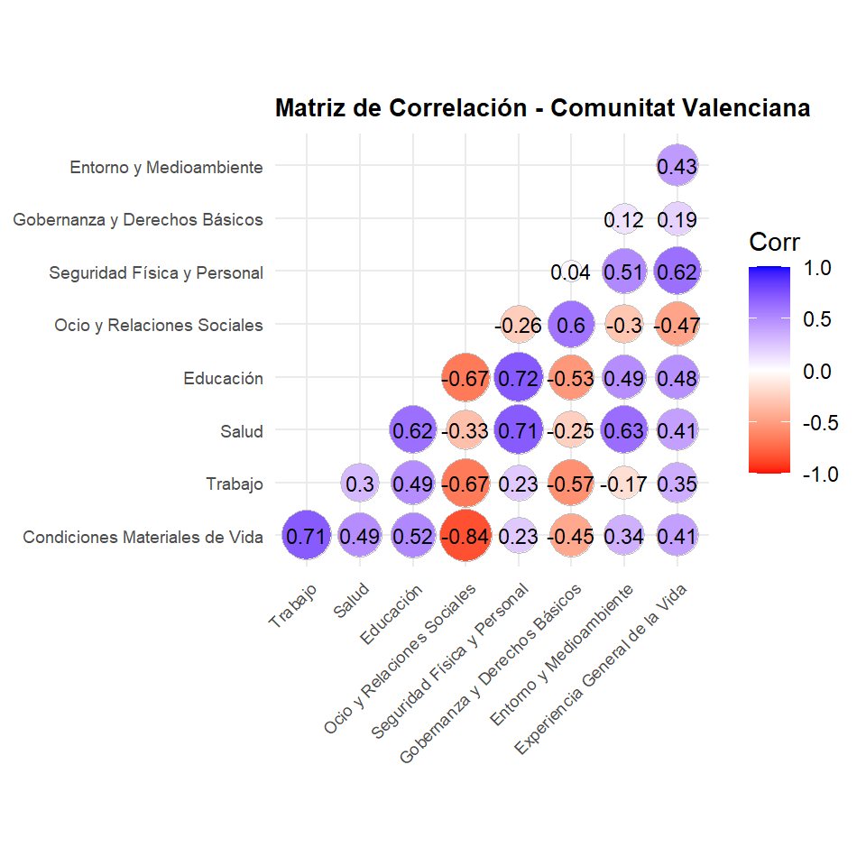

Siguiendo con el análisis, dado el volumen de datos disponibles, procedemos a simplificar el conjunto calculando un promedio de todas las dimensiones para obtener un valor global de calidad de vida por comunidad autónoma y por año. Este enfoque nos permite mantener la representatividad de todas las dimensiones sin perder información relevante.

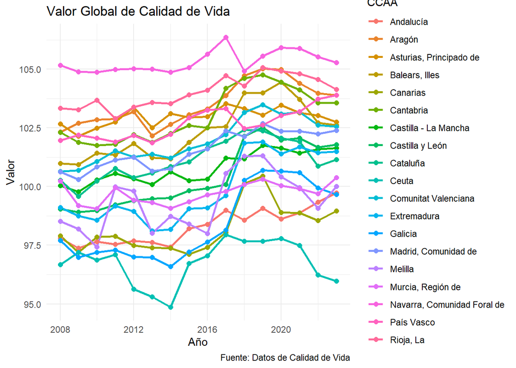

En la gráfica anterior se puede observar el índice global de calidad de vida en las diferentes comunidades autónomas de España a lo largo del tiempo. Notamos que, en general, las comunidades y ciudades autónomas presentan una tendencia creciente para este índice (especialmente después de 2015), aunque en los últimos años se puede apreciar una ligera caída general. La mayoría de las comunidades y ciudades autónomas han experimentado estos fenómenos con poca variabilidad alrededor de su tendencia, a excepción de alguna que sí que presenta gran variabilidad.

El País Vasco y la Comunidad Foral de Navarra son las comunidades que presentan un índice más alto, que además se ha mantenido a lo largo del tiempo. Por otro lado, Ceuta presenta los valores más bajos en el conjunto, mantenidos a lo largo del tiempo. En los últimos años, se puede apreciar que Ceuta ha sufrido una caída alcanzando un índice en el último año que es notablemente más bajo que el de el resto de comunidades o ciudades autónomas. Parece haber disparidad entre ciertos grupos de comunidades y ciudades autónomas.

Es por esto, que vamos a realizar un histograma con 3 bines correspondientes a las categorías de clase alta, media y baja donde agruparemos las comunidades autónomas, basado en el valor global de calidad de vida. Este análisis permitirá visualizar cómo evoluciona la distribución de estas clases a lo largo del tiempo, identificando posibles cambios en la composición de las comunidades autónomas dentro de cada categoría.

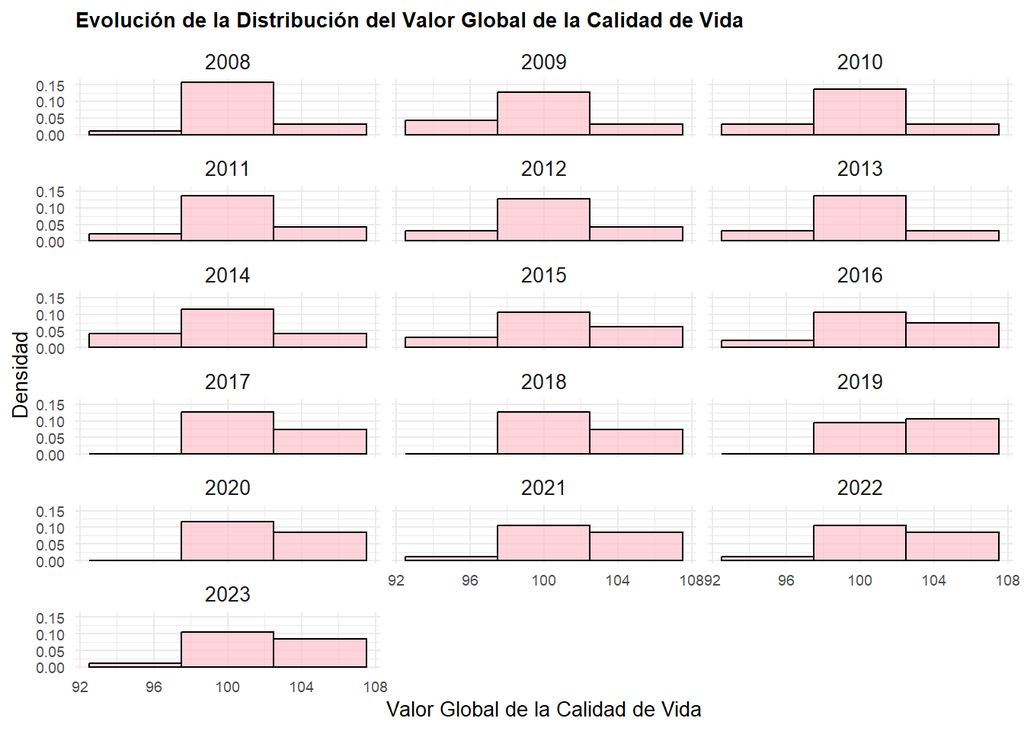

Lo primero que llama la atención es que entre 2008 y 2009, se observa un aumento notable en la proporción de comunidades autónomas con valores más bajos de calidad de vida, lo que coincide con el impacto de la crisis económica en España. Esto sugiere un desplazamiento hacia la clase baja en ese período, posiblemente debido a los problemas económicos que afectó a diversas dimesiones sociales y económicas. A lo largo de los años siguientes, las distribuciones parecen recuperar cierta estabilidad, con una concentración gradual hacia valores medios en la mayoría de las comunidades autónomas. Sin embargo, el rango de valores permanece relativamente constante, indicando que las desigualdades entre las comunidades autónomas persisten.

Otro factor que llama la atención en los histogramas es que entre 2018 y 2019 la clase alta aumenta de manera considerable. Esto podría estar relacionado con eventos como el incremento del salario mínimo interprofesional en 2019, que pasó de 735.9€ a 900€ mensuales, beneficiando especialmente a las regiones con sectores de bajos ingresos. Además, la recuperación sostenida del empleo, con una significativa disminución de la tasa de paro, y el rendimiento positivo del turismo en comunidades como Baleares, Canarias, Cataluña y Comunidad Valenciana, también jugaron un papel clave. Estas mejoras se complementaron con un mayor gasto público en sanidad, educación y políticas sociales, contribuyendo a fortalecer los dimensiones de bienestar en varias comunidades autónomas, añadiéndolas en la clase alta.

Debido a esto, clasificaremos las comunidades autónomas en clústeres que representen tres niveles: clase baja, media y alta, según su calidad de vida. Esto nos permitirá trabajar con menos datos de forma más manejable, conservando la gran parte de la información.

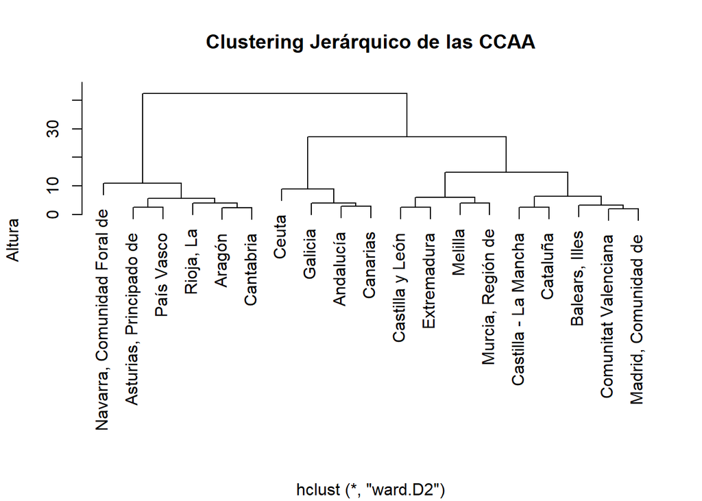

En el dendograma se puede observar la separación de las comunidades autonomas en tres clases. Tras obtener las agrupaciones, notamos que las comunidades autónomas que forman cada clase son:

Clase alta: Aragón, Principado de Asturias, Cantabria, Comunidad Foral de Navarra, País Vasco, y La Rioja. Clase media: Illes Balears, Castilla - La Mancha, Castilla y León, Cataluña, Comunitat Valenciana, Extremadura, Comunidad de Madrid, Melilla, y Región de Murcia. Clase baja: Andalucía, Canarias, Ceuta, Galicia.

Vemos que en el caso de la clase alta tenemos una subagrupación la cuál distingue la Comunidad Foral de Navarra del resto, por la tanto podemos esperar que en el análisis posterior de la clase alta la Comunidad Foral de Navarra sea la que más difiera del comportamiento general del grupo. En el caso de la clase media, tenemos dos subagrupaciones que contienen cuatro y cinco comunidades autónomas, por lo que no cabría esperar comportamientos fuera de la generalidad del grupo. Finalmente, para la clase baja sucede lo mismo que para la clase alta, en este caso Ceuta es la comunidad que más difiere de su clase.

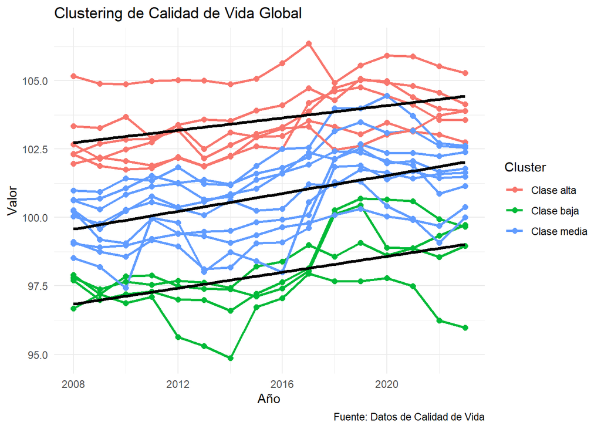

Cluster 1: Valor_Global = 0.1130·Año - 124.0787, multiple R-squared = 0.2073, p-value = 3.14e-06.

Cluster 2: Valor_Global = 0.1633·Año - 228.3370, multiple R-squared = 0.2886, p-value = 3.88e-12.

Cluster 3: Valor_Global = 0.1455·Año - 195.3640, multiple R-squared = 0.2791, p-value = 7.234e-06.

Asimismo, se puede apreciar en la gráfica que las tres agrupaciones presentan una tendencia lineal general creciente y muy similar entre ellas. Sin embargo, cabe destacar que, si bien la mayoría de las comunidades autónomas han experimentado un aumento de su índice de calidad de vida con poca variación, hay alguna comunidad autónoma que sí presenta grandes variaciones alrededor de su tendencia a lo largo del tiempo. Además, notamos que, a lo largo del tiempo, a penas hay solapamiento entre las agrupaciones, excepto en el último lustro. Este solapamiento cesa en el último año registrado.

En la gráfica, se puede observar la recta de regresión ajustada a cada agrupación. Los dos coeficientes de cada recta son significativos a nivel $\alpha = 0.05$. Hay evidencia estadística a favor de la hipótesis sobre la tendencia lineal y creciente en los índices de las tres agrupaciones. Además, las pendientes de las rectas son muy similares. Por otro lado, la diferencia de altura entre las rectas de la clase alta y de la media es muy similar a la diferencia de altura entre las rectas de la clase media y de la baja. El valor de esta diferencia es de aproximadamente $3$ puntos, i.e., hay una clara diferencia entre las clases.

Finalmente, notamos que a penas hay solapamiento entre las agrupaciones a lo largo del tiempo, excepto en el último lustro. Este solapamiento cesa en el último año registrado. La clase alta presenta un crecimiento estable a lo largo del tiempo. La clase media presenta un crecimiento generalmente estable hasta 2017, donde experimenta un gran crecimiento relativo que se estanca decrece ligeramente posteriormente (a partir de 2019). La clase baja presenta un estancamiento genereal hasta 2015, donde experimenta un crecimiento general (que en algunos casos es superlativo), y posteriormente experimenta un decaimiento general (a partir de 2019).

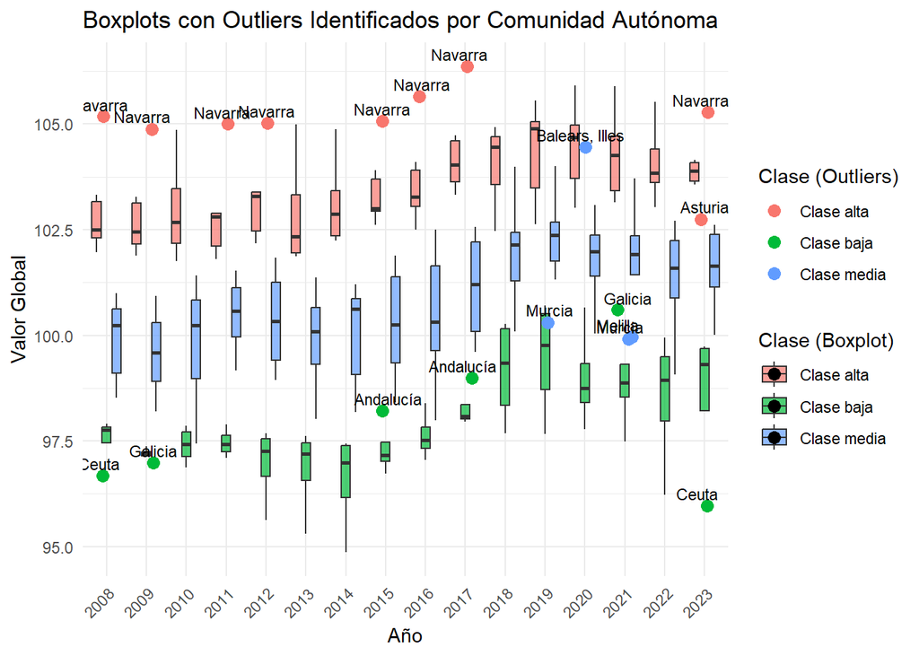

Observando la gráfica anterior, observamos que hay algunos valores extremos a lo largo del tiempo presentes en las agrupaciones. A través de las etiquetas asociadas a cada valor extremo, que identifican a qué comunidad o ciudad autónoma pertenece cada uno, verificamos algunas observaciones previas, y además logramos divisar nuevas observaciones.

Los valores extremos superiores de la clase alta pertenecen a la Comunidad Foral de Navarra; y el valor extremo inferior de la clase alta en el último año pertenece al Principado de Asturias. El valor extremo superior de la clase media en 2020 pertenece a les Illes Balears; y los valores extremos inferiores de la clase media pertenecen a la Región de Murcia (2019 y 2021) y a Melilla (2021). Los valores extremos superiores de la clase baja pertenecen a Andalucía (2015 y 2017) y a Galicia (2021); y los valores extremos inferiores de la clase baja pertenecen a Ceuta (2008 y 2023) y a Galicia (2009).

Habiendo observado estos valores extremos, volvemos a apreciar como la Comunidad Foral de Navarra ha líderado el conjunto con el mayor índice, con diferencia, del conjunto en su totalidad. Ceuta se ha mantenido con valores extremos alcanzando índices muy bajos comparados con los del resto de observaciones. Asimismo, Ceuta no ha experimentado ese crecimiento generalizado que sí se ha experimentado, en general, en el conjunto. Por último, notamos que Galicia ha experimentado un gran crecimiento a lo largo del período estudiado, llegando a superar a la Región de Murcia y a Melilla en algún año (como en 2021), que son miembros de la clase media.

## Conclusiones

Tras realizar el análisis de los datos, en todos los apartados hemos obtenido que la comunidad que destaca con un mayor índice es Navarra y en contraposición la de un índice más bajo ha sido Ceuta.

La división de las CCAA según el nivel de vida diferencia las CCAA en tres clases. Hemos obtenido que de las 19 comunidades autónomas únicamente 4 de ellas pertenecen a la clase baja (alrededor del 21%), 9 pertenecen a la clase media (47%) y 6 a la clase alta (32%). Por tanto, podemos decir que en general la calidad de vida en España es mayoritariamente media-alta.

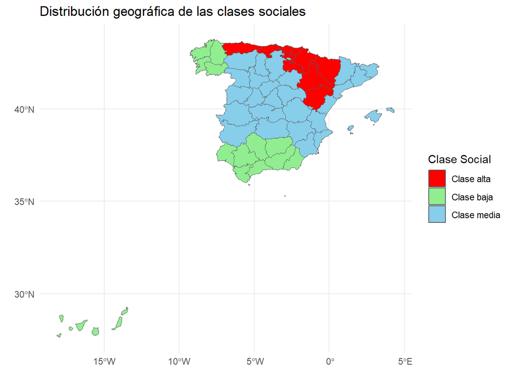

Con todo esto, en este trabajo hemos explorado la calidad de vida en España desde un enfoque multidimensional, utilizando datos estructurados por comunidad autónoma y año. A través de técnicas como el análisis de correlación, hemos identificado relaciones clave entre dimensiones como condiciones materiales, trabajo y educación, que forman el núcleo del bienestar socioeconómico. También hemos aplicado métodos de agrupamiento, como clústeres jerárquicos, para clasificar las comunidades autónomas en clases alta, media y baja, lo que nos ha permitido simplificar el análisis sin perder representatividad de los datos. Estas clasificaciones han facilitado el estudio de tendencias o eventos como la crisis económica de 2008 y la recuperación posterior Finalmente, mediante visualizaciones como histogramas, boxplots, hemos destacado tanto la evolución general de la calidad de vida como las desigualdades persistentes entre las comunidades. Estos resultados proporcionan nos permiten comprender el bienestar de cada comunidad de España.